# Day 1: Intro to R & tidyverse Supplementary Notebook

Stephanie J. Spielman

2022-09-20

## Introduction

This notebook addresses some questions that came up after the first day of the CCDL workshop.

- RDS and RData formats
- Labeling individual points in plots

### How to use this notebook:

While it is fine to just read this page as is, if you want to get the Rmarkdown notebook itself to work with, you can follow the following steps:

1. Click the `Code` button in the upper right of this page and choose `Download Rmd` to save this notebook (`2022-09-20_muddiest_points.Rmd`) to your computer. If you have RStudio installed on your computer, you can then open the file directly.

Otherwise you can add it to the CCDL RStudio server to work with it there with the following additional steps:

2. Navigate to RStudio server.
3. In the `File` pane, navigate to `training-modules/intro-to-R-tidyverse`.
4. Click the `Upload` button in the `File` pane.
5. Click `Choose file` and find this `Rmd` file on your computer, then click `OK`

Now you can open up this file and run it on the RStudio Server.

## RDS and RData formats

As we discussed in the Introduction to Tidyverse lesson, there is an R-specific file format called “RDS” (R Data Serialized/Single). This file format will store data exactly as you have it in your R environment, making it easy to export and load in any kind of R object (aka variable). In addition, RDS files can be compressed, meaning they will take up less space on your computer. In base R, RDS files can be saved with the function `saveRDS()` and read in with `readRDS()`. There are complementary functions in the `readr` package, `readr::write_rds()` and `readr::read_rds()`, that can be used instead. The main difference between base R and tidyverse versions of these functions is that, when writing to a file, `saveRDS()` will compress the data by default but `readr::write_rds()` will not unless you explicitly specify a compression method with the `compress` argument (see `?readr::write_rds()` for help!).

There is a second kind of R-specific file format for exporting data called “RData,” which you might see as files with the extension “.Rda”. Like RDS files, RData files save R objects in exactly as they are in your R environment, and we use functions `save()` and `load()` to export and read them.

However, we at the Data Lab strongly prefer RDS files to RData files when exporting R-specific data objects. We mainly have this preference because you, the programmer and scientist, have *much more control* over an object loaded from an RDS file vs. an RData file.

First, RDS files can only contain one object, but RData files can contain an arbitrary number of objects. We like files to only contain one object, so that we when read in a file, we are explicitly reading in one object corresponding to that file. Otherwise, we might be loading in multiple objects that could interfere with our environment, and we wouldn’t necessarily know about it! If there are multiple R-specific data formats you wish to export to files, we recommend creating a separate RDS file for each.

Second, RDS files only store the representation of the object itself, *not* its name. By contrast, RData files retain the name of any object you save; when you load an RData file, all object(s) in that file are automatically loaded into your current R session with whatever variable names they had at the initial export. This can get a little dangerous and lead to unintended code bugs, because you are loading variables into your R environment without explicitly naming those variables yourself! For example, imagine you have defined an object called `sce` that contains a `SingleCellExperiment` object in your R session. Then, you load an RData file that contains some data you want to use. It is entirely possible that, *without your knowledge*, that RData file could have been storing a dataset also named `sce`. This would *overwrite* and effectively delete your `sce` variable, which will end up breaking all of your code.

This difference can be partly seen in the way we read RDS vs RData files, for example:

```r
# Read in an RDS file and save to a variable called `my_data`
my_data <- readr::read_rds("my_rds_file.rds")


# Read in an RDA file, but we don't save it to a variable, because
#  whatever variable name the given data had when it was saved to the
#  RData file long, long ago will be created automatically in the R session
load("my_rda_file.rda")
```

You’ll notice that when using `load()`, we don’t actually create a variable - this is because variables stored in the RData file are just automatically placed into your R environment, and as mentioned, that has potential to cause frustrating bugs.

So, if you have RData files you are now interested in converting to RDS files, you can do the following:

- Use `load()` to load in your RData file
- Look at your environment pane to see the names of the variables that were loaded in. You can also use the R command `ls()` to see all defined variables in the current session.
- Determine which objects you want to save as RDS files, and export *each separately* as an RDS file, with either `saveRDS()` or `readr::write_rds()`.

## Labeling individual points in plots

Often, we wish to label points in plots, for example labeling individual points (e.g. points representing genes of interest) in a volcano plot. The example code below shows you how to include labeling for a subset of points of interest.

First, let’s create a toy dataset to plot with. Here, I’ve taken a random subset of 10 “male_female” contrast rows from the data frame we plotted in during the [Introduction to `ggplot2` session](https://htmlpreview.github.io/?https://github.com/AlexsLemonade/training-modules/blob/2022-september/intro-to-R-tidyverse/02-intro_to_ggplot2.nb.html).

```r
# Create a small dataset to use here as a plotting example.
gene_data <- data.frame(
  gene_symbol = c("BOLA3",  "ATP6V0E2",  "ATG12",  "ASCL1",  "PSMC5",  "IMPA1",  "FABP7",  "SCARB2",  "FRMD6",  "SKA2"),
  log_fold_change = c(1.46,  10.9,  0.168,  -1.39,  8.94,  -1.10,  -5.15,  -3.28,  2.33,  6.35),
  neg_log10_p = c(0.378, 2.05, 0.128, 0.418, 3.12, 0.506, 1.70, 4.37, 0.929, 5.10)
)

# Print the data:
gene_data
```

| gene_symbol | log_fold_change | neg_log10_p |
| --- | --- | --- |
| BOLA3 | 1.460 | 0.378 |
| ATP6V0E2 | 10.900 | 2.050 |
| ATG12 | 0.168 | 0.128 |
| ASCL1 | -1.390 | 0.418 |
| PSMC5 | 8.940 | 3.120 |
| IMPA1 | -1.100 | 0.506 |
| FABP7 | -5.150 | 1.700 |
| SCARB2 | -3.280 | 4.370 |
| FRMD6 | 2.330 | 0.929 |
| SKA2 | 6.350 | 5.100 |

Now, let’s make a plot where we also label points whose log fold change is greater than 5 (for the purposes of this example, we won’t worry too much about significant p-values!). A helpful R package for labeling points, while ensuring those labels do not overlap one another, is [`ggrepel`](https://ggrepel.slowkow.com/). We’ll use the function `geom_text_repel()` from this package to create our labels. If you are using this package for the first time, you’ll have to install it with `install.packages()`:

```r
install.packages("ggrepel")
```

First, let’s plot a regular volcano plot without point labels, as we did during the workshop.

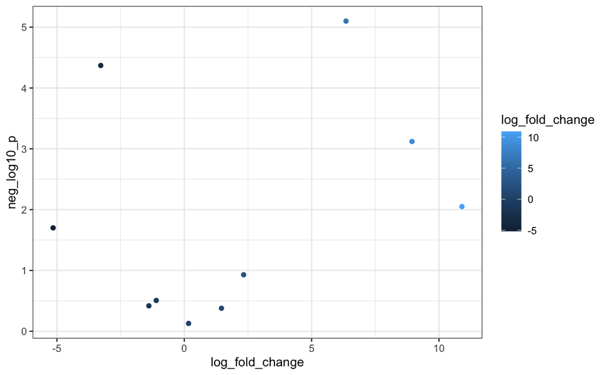

```r
# Load libraries needed for plotting:
library(ggplot2)
library(ggrepel)

ggplot(
  gene_data,
  aes(
    x = log_fold_change,
    y = neg_log10_p,
    color = log_fold_change
  )
) +
  geom_point() +
  theme_bw() # add bw theme
```

Now, let’s add some labels with the `ggrepel` function `geom_text_repel()`, again focusing only on points with >5 log fold change.

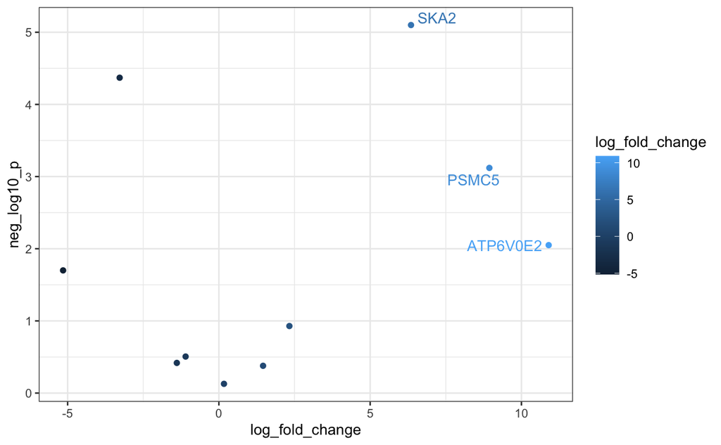

```r
ggplot(
  gene_data,
  aes(
    x = log_fold_change,
    y = neg_log10_p,
    color = log_fold_change
  )
) +
  geom_point() +
  # This layer adds labels:
  geom_text_repel(
    # First, we want only a subset of data,which we can specify with the `data` argument.
    # We can use dplyr::filter for this!
    data = dplyr::filter(gene_data, log_fold_change > 5),
    # Next, we set up the label to map to the `gene_symbol` column in our data
    aes(label = gene_symbol)
  ) +
  theme_bw()
```

If you prefer that all labels are the same color rather than matching the color of their points, you can specify by adding a `color` argument to `geom_text_repel`:

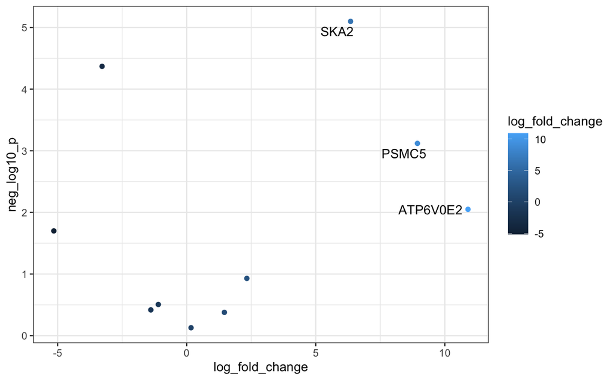

```r
ggplot(
  gene_data,
  aes(
    x = log_fold_change,
    y = neg_log10_p,
    color = log_fold_change
  )
) +
  geom_point() +
  # This layer adds labels:
  geom_text_repel(
    # First, we want only a subset of data,which we can specify with the `data` argument.
    # We can use dplyr::filter for this!
    data = dplyr::filter(gene_data, log_fold_change > 5),
    # Next, we set up the label to map to the `gene_symbol` column in our data
    aes(label = gene_symbol),
    # Specify the same color (here, black) for all points
    color = "black"
  ) +
  theme_bw()
```

We’ll also point out this super useful Bionconductor package for volcano plots called [`EnhancedVolcano`](https://bioconductor.org/packages/release/bioc/vignettes/EnhancedVolcano/inst/doc/EnhancedVolcano.html), which can automatically take care of a lot of labeling and styling for you, without needing to use `ggplot2` directly. Handily though, the plots it creates *are* `ggplot2` plots, so you can customize them further with the same layer syntax that you have been using! You can also [peruse this material](https://github.com/AlexsLemonade/training-modules/blob/fa3abe50c17ca369b352ae22e2367096a51fef5f/RNA-seq/05-nb_cell_line_DESeq2.Rmd) from a different workshop of ours on Bulk RNA-Seq analysis where we introduce this package, as another example of some genomic data visualization.